# Insights - Tabela de Dados da Aeronaútica

# Introdução

A ideia desse documento é pegar um dataset com qual não tenho familiaridade e tentar extrair algum tipo de *insight* ou algum fato interessante usando R, usando especialmente data.table, Rmarkdown para compilar um documento de como fui me mergulhando nos dados junto com alguns htmlwidgets no caminho, e possivelmente criar um demo de um aplicativo shiny no final.

Nesse caso, escolhi um dataset que me interessou sobre **Ocorrências Aeronáuticas na Aviação Civil Brasileira**. Imagino que terá como mexer um pouco com mapas usando Leatlet ou alguma outra direção que quisermos tomar.

Esses datasets são extraídos da CENIPA e estão disponíveis no [site de dados abertos do Governo Federal](https://dados.gov.br/dataset/ocorrencias-aeronauticas-da-aviacao-civil-brasileira).

Segue uma breve descrição do que está no site:

> A base de dados de ocorrências aeronáuticas é gerenciada pelo Centro de Investigação e Prevenção de Acidentes Aeronáuticos (CENIPA). Constam nesta base de dados as ocorrências aeronáuticas notificadas ao CENIPA nos últimos 10 anos e que ocorreram em solo brasileiro.

> Dentre as informações disponíveis estão os dados sobre as aeronaves envolvidas, fatalidades, local, data, horário dos eventos e informações taxonômicas típicas das investigações de acidentes (AIG). São resguardadas a privacidade de pessoas físicas/jurídicas envolvidas conforme previsto pela Lei de Acesso à Informação (Lei n° 12.527, de 18 de novembro de 2011).
- Informações dos dados utilizados nesse relatório:

| **Campo** | **Valor** |
| --- | --- |
| Fonte | http://www.fab.mil.br/cenipa/ |
| Autor | Centro de Investigação e Prevenção de Acidentes Aeronáuticos |
| Mantenedor | Centro de Investigação e Prevenção de Acidentes Aeronáuticos |
| Versão | 1.3 |
| Última Atualização | 5 de Outubro de 2021, 19:19 (UTC-03:00) |
| Criado | 1 de Junho de 2015, 15:37 (UTC-03:00) |
| Cobertura geográfica | Brasil |
| Cobertura temporal | 2010 a 2019 |
| Fale Conosco | estatistica.cenipa@fab.mil.br |
| Frequência de atualização | Anual |
| Granularidade geográfica | Aeródromo |
| Granularidade temporal | Hora:Minuto |
| VCGE | Aeronáutica [http://vocab.e.gov.br/2011/03/vcge#aeronautica], Transporte Aéreo [http://vocab.e.gov.br/2011/03/vcge#transporte-aereo] |

# Importação e Tratamentos Iniciais dos Dados

## Importação dos Dados

Bom, iniciamos o programa importando as informações do portal da CENIPA (Centro de Investigação e Prevenção de Acidentes Aeronáuticos) encontrados no link mencionados na Introdução.

Note que se importarmos o programa sem especificar o encoding como “UTF-8”, então caracteres especiais do Português Brasil serão lidos incorretamente. e.g. “ã”, “é”, “Ç”, etc.

```r
# Tabela Central - Ocorrência
ocorrencia <- data.table::fread(
  "http://sistema.cenipa.aer.mil.br/cenipa/media/opendata/ocorrencia.csv",
  encoding = "UTF-8"
)

# Tabela Complementar 1 - Código de Ocorrência 1
ocorrencia_tipo <- data.table::fread(
  "http://sistema.cenipa.aer.mil.br/cenipa/media/opendata/ocorrencia_tipo.csv",
  encoding = "UTF-8"
)

# Tabela Complementar 2 - Código de Ocorrência 2
aeronave <- data.table::fread(
  "http://sistema.cenipa.aer.mil.br/cenipa/media/opendata/aeronave.csv",
  encoding = "UTF-8"
)

# Tabela Complementar 3 - Código de Ocorrência 3
fator_contribuinte <- data.table::fread(
  "http://sistema.cenipa.aer.mil.br/cenipa/media/opendata/fator_contribuinte.csv",
  encoding = "UTF-8"
)

# Tabela Complementar 4 - Código de Ocorrência 4
recomendacao <- data.table::fread(
  "http://sistema.cenipa.aer.mil.br/cenipa/media/opendata/recomendacao.csv",
  encoding = "UTF-8"
)
```

## Cruzamento dos Dados

### Explicação

Normalmente, essa seria um bom momento de dar uma olhada em algumas colunas e vermos o que podemos fazer com elas. No entanto, lendo as informações no site de dados do Governo Federal, notamos que apesar de termos 5 tabelas diferentes, há uma tabela central que possui informações adicionais distribuídas nas outras 4, assim como na imagem a seguir:

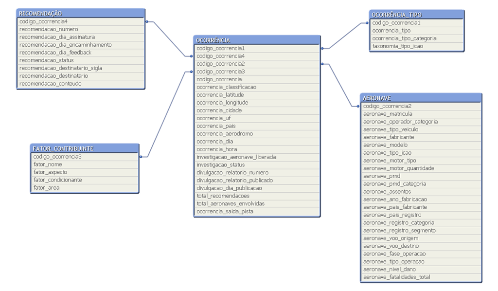

Como as tabelas são bem pequenas com menos 10 mil linhas e 30 colunas, cruzá-las e trazer todas as informações em um único dataset poderá facilitar o tratamento de dados mais para frente. Talvez fique um pouco mais difícil de ter uma panorama geral só batendo o olho, mas dado o número colunas parece ser algo tolerável.

Como estou usando o pacote data.table, vamos utilizá-lo para cruzar as informações baseado na chave seguindo a imagem do relacionamento de dados das tabelas acima. Extraindo as informações, seria algum assim:

| nome_tabelas_complementares | chave_tabelas_complementares |
| --- | --- |
| ['OCORRENCIA_TIPO'] | ['codigo_ocorrencia1'] |
| ['AERONAVE'] | ['codigo_ocorrencia2'] |
| ['FATOR_CONTRIBUINTE'] | ['codigo_ocorrencia3'] |
| ['RECOMENDACAO'] | ['codigo_ocorrencia4'] |

### Cruzamento

Primeira coisa, vamos dar um head para ter um panorama geral da tabela central, *ocorrencia* - especialmente das chaves. Nunca se sabe se algo deu errado.

```r
head(ocorrencia[, c("codigo_ocorrencia", "codigo_ocorrencia1", "codigo_ocorrencia2", "codigo_ocorrencia3", "codigo_ocorrencia4")])
```

```
##    codigo_ocorrencia codigo_ocorrencia1 codigo_ocorrencia2 codigo_ocorrencia3
## 1:             40211              40211              40211              40211
## 2:             40349              40349              40349              40349
## 3:             40351              40351              40351              40351
## 4:             39527              39527              39527              39527
## 5:             40324              40324              40324              40324
## 6:             39807              39807              39807              39807
##    codigo_ocorrencia4
## 1:              40211
## 2:              40349
## 3:              40351
## 4:              39527
## 5:              40324
## 6:              39807
```

Note que isso não significa que todas as linhas serão iguais. Porém, há uma leve suspeita para sabermos se isso é muito mais que uma mera coincidência.

Para checarmos no R se as colunas possuem valores, iguais podemos usar a função *identical* para saber se os elementos são iguais.

```r
identical(
  ocorrencia[, codigo_ocorrencia],
  ocorrencia[, codigo_ocorrencia1],
  ocorrencia[, codigo_ocorrencia2],
  ocorrencia[, codigo_ocorrencia3],
  ocorrencia[, codigo_ocorrencia4]
)
```

```
## [1] TRUE
```

Isso não mudará muita coisa no nosso cruzamento, mas isso significa que podemos descartar alguns dados mais para frente, pós o cruzamento.

Voltando ao que interessa, vamos para o cruzamento - fazendo 4 left joins seguidos:

```r
cruzamento1 <- ocorrencia[ocorrencia_tipo, on = "codigo_ocorrencia1"] # Left Join 1
cruzamento2 <- cruzamento1[aeronave, on = "codigo_ocorrencia2"] # Left Join 2
cruzamento3 <- cruzamento2[fator_contribuinte, on = "codigo_ocorrencia3"] # Left Join 3
# tabela <- cruzamento3[recomendacao, on = "codigo_ocorrencia4"] # Left Join 4
```

Rodando o código acima sem a última linha estar comentada, obteremos um erro vindo do último cruzamento, um left join entre *ocorrencia* e *recomendacao*:

> Error in vecseq(f__, len**, if (allow.cartesian || notjoin || !anyDuplicated(f**, : Join results in 11387 rows; more than 6687 = nrow(x)+nrow(i). Check for duplicate key values in i each of which join to the same group in x over and over again. If that’s ok, try by=.EACHI to run j for each group to avoid the large allocation. If you are sure you wish to proceed, rerun with allow.cartesian=TRUE. Otherwise, please search for this error message in the FAQ, Wiki, Stack Overflow and data.table issue tracker for advice.

Aparentemente as chaves de alguma das duas tabelas não são únicas. Vamos dar uma olhadinha na frequências das chaves (código de ocorrência - *codigo_ocorrencia*) das tabelas:

```r
head(ocorrencia[, .(n = .N), by = codigo_ocorrencia][n > 1][order(-n)])
```

```
## Empty data.table (0 rows and 2 cols): codigo_ocorrencia,n
```

```r
head(ocorrencia_tipo[, .(n = .N), by = codigo_ocorrencia1][n > 1][order(-n)])
```

```
##    codigo_ocorrencia1 n
## 1:              66444 3
## 2:              78780 3
## 3:              78879 3
## 4:              78904 3
## 5:              79620 3
## 6:              79651 3
```

```r
head(aeronave[, .(n = .N), by = codigo_ocorrencia2][n > 1][order(-n)])
```

```
##    codigo_ocorrencia2 n
## 1:              45689 3
## 2:              78249 3
## 3:              79441 3
## 4:              41609 2
## 5:              43869 2
## 6:              44944 2
```

```r
head(fator_contribuinte[, .(n = .N), by = codigo_ocorrencia3][n > 1][order(-n)])
```

```
##    codigo_ocorrencia3  n
## 1:              41053 19
## 2:              42250 19
## 3:              42921 19
## 4:              44660 18
## 5:              44796 18
## 6:              53340 17
```

```r
head(recomendacao[, .(n = .N), by = codigo_ocorrencia4][n > 1][order(-n)])
```

```
##    codigo_ocorrencia4  n
## 1:              44796 23
## 2:              45554 20
## 3:              42250 19
## 4:              52265 13
## 5:              66432 12
## 6:              39992 11
```

Bom, dado que não há uma chave comum entre as tabelas que não estejam duplicadas, não é possível fazer um join direto entre elas. No entanto, como nossas tabelas não possuem nenhum campo de valor que poderíamos agregar (exceto 3 colunas que contém o nome “total”, mas que podem ser recalculadas usando as variáveis de origem), nós conseguimos fazer algo ainda que nos ajude a colocar tudo numa tabela só, usando cruzamento cartesiano (*cartesian join*).

Então, para fazer o cruzamento cartesiano no data.table basta especificar o argumento no final. Vamos ver se agora dará certo…

```r
cruzamento1 <- ocorrencia_tipo[ocorrencia, on = "codigo_ocorrencia1", allow.cartesian = TRUE] # Left Join 1
cruzamento2 <- aeronave[cruzamento1, on = "codigo_ocorrencia2", allow.cartesian = TRUE] # Left Join 2
cruzamento3 <- fator_contribuinte[cruzamento2, on = "codigo_ocorrencia3", allow.cartesian = TRUE] # Left Join 3
tabela <- recomendacao[cruzamento3, on = "codigo_ocorrencia4", allow.cartesian = TRUE] # Left Join 4

head(tabela)
```

```
##    codigo_ocorrencia4 recomendacao_numero recomendacao_dia_assinatura
## 1:              40211                <NA>                        <NA>
## 2:              40349                <NA>                        <NA>
## 3:              40351                <NA>                        <NA>
## 4:              39527                <NA>                        <NA>
## 5:              39527                <NA>                        <NA>
## 6:              39527                <NA>                        <NA>
##    recomendacao_dia_encaminhamento recomendacao_dia_feedback
## 1:                            <NA>                      <NA>
## 2:                            <NA>                      <NA>
## 3:                            <NA>                      <NA>
## 4:                            <NA>                      <NA>
## 5:                            <NA>                      <NA>
## 6:                            <NA>                      <NA>
##    recomendacao_conteudo recomendacao_status recomendacao_destinatario_sigla
```

[output cut: 139 more lines]

E sucesso! *Wheeeew.* Agora que temos uma tabela com todas as informações que precisamos, podemos criar algumas visões para tirar alguns insights ou análises interessantes sobre :)